# BAYESIAN MODELING OF MICROBIOME DATA FOR DIFFERENTIAL ABUNDANCE ANALYSIS

## Tutorial

The following script is used to perform differential abundance analysis for microbiome count data using the proposed Zero-inflated Negative Binomial model with Dirichlet Process Prior (ZINB-DPP) model in the manuscript Q.Li *et al. 2019* https://arxiv.org/abs/1902.08741.

## Loading Data

We first load a simulated $n$-by-$p$ micribiome count dataset. Here, we simulate $n = 24$ and $p = 1000$.

```r
Y = read.table("../Github_Code/data/simulation_single.txt")
Y = as.matrix(Y)
n = nrow(Y); p = ncol(Y)
```

We also need the phenotype indicator vector of the $n$ samples. Each element in the indicator vector is a binary variable with value of either $1$ or $0$. Here, we have 2 groups with a balanced group size of $12$.

```r
group_info = rownames(Y)
z_vector = substr(group_info, nchar(group_info), nchar(group_info))
z_vector = as.numeric(z_vector) - 1
```

Before fitting the model, we get the true discriminating taxa by creating a binary vector `gamma_true`, where $1$ represents that the taxon is discriminating and $0$ otherwise.

```r
gamma_true = rep(0, dim(Y)[2])
gamma_true[grep(".TP", colnames(Y))] = 1
```

## Loading Main Function

We load the main function of the ZINB-DPP model:

```r
library(Rcpp)
sourceCpp('../Github_Code/utility/core_zinb_x5.cpp')
```

We set all the model parameter by default and fit the model:

```r
s_sizefactor = rep(1, n)
Niter = 10000
S = matrix(1, 1, 1)
G = matrix(1, 1, 1)
b = 1
h = 10

# set a random seed #
set.seed(198642)

# run zinb-dpp model #
zinbdpp_output = zinb_model_estimator(Y = Y, z = z_vector,
s = s_sizefactor, iter = Niter, DPP = TRUE, b = b, h = h,S = S, G = G,store = TRUE, aggregate = FALSE, MRF = F)
```

```
## 0% has been done
## 10% has been done
## 20% has been done
## 30% has been done
## 40% has been done
## 50% has been done
## 60% has been done
## 70% has been done
## 80% has been done
## 90% has been done
```

## Evaluation

Now, we evaluate our model by visualizing the result of the differential abundance analysis.

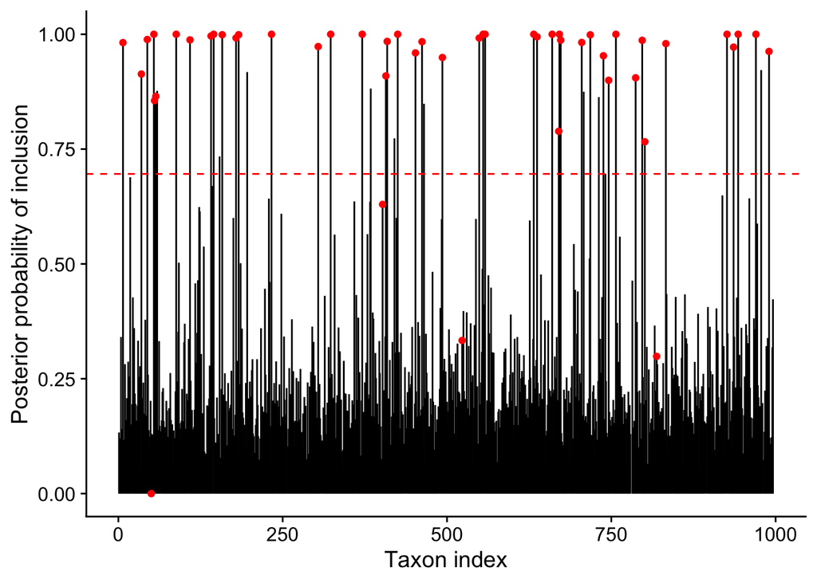

```r
# load function to calculate the threshold that
# controls the Bayesian false discovery rate
source('../Github_Code/utility/user_functions.R');

zinbdpp_PPI = zinbdpp_output$gamma_ppi
c_gamma = BayFDR(PPI = zinbdpp_PPI, alpha = 0.05)
ppi_df = data.frame(x = seq(1, length(zinbdpp_PPI)),
                    y = zinbdpp_PPI)
ppi_point_df = data.frame(x = which(gamma_true == 1),
                          y = zinbdpp_PPI[which(gamma_true == 1)])
ggplot(ppi_df,
       aes(x = x,xend = x, y = 0, yend = y) ) +
  geom_segment() +
  geom_point(data = ppi_point_df, aes(x, y), color = 'red')+
  geom_hline(yintercept = c_gamma, linetype = "dashed", color = 'red') +
  xlab("Taxon index") + ylab("Posterior probability of inclusion")
```

Each vertial line is the posterior proability of inclusion (PPI) of a taxon. The dashed line represent the threshold that control the Bayesian false discovery rate to be less than $0.05$. Taxa whose PPIs exceed the dashed line would be selected as the differentially abundant taxa.

## Size Factor Estimation

We can also check the estimation of the size factors for all $n = 24$ samples in the data.

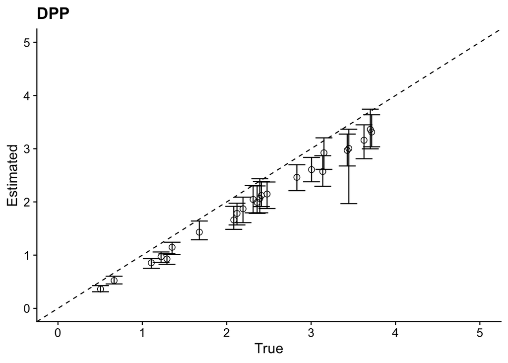

```r
# Load true size factors
s_true = read.table("../Github_Code/data/true_size_factor.txt")
s_true = as.vector(s_true)

# Load estimated size factors
s_mcmc = zinbdpp_output$s
si_df_dpp = data.frame(st = s_true,
                       dpp = apply(s_mcmc, 2, mean),
                       low = apply(s_mcmc, 2, quantile, 0.025),
                       up = apply(s_mcmc, 2, quantile, 0.975))
colnames(si_df_dpp)[1] = "st"

# Compare true and estimated size factors
ggplot(si_df_dpp, aes(st, dpp)) +
  geom_errorbar(aes(ymin = low,ymax = up),width = 0.2)+
  geom_point(colour = "black", size = 2.5, shape=1) +
  ylim(0, 5)+xlim(0, 5)+xlab("True")+ylab("Estimated")+ggtitle("DPP") +
  geom_abline(intercept = 0, slope = 1, linetype = "dashed")
```

In the figure above, each vertical bar is a $95\%$ credible interval estimation of the corresponding size factor, with the posterior mean in the middle.

## Result Reproduce

Please refer to R code `demo_code.R` to reproduce all the above results.

## Contact

Qiwei Li, Department of Mathematical Science, The University of Texas at Dallas, Richardson, Texas liqiwei2000@gmail.com